# Analyzing Transaction data like a data scientist

Part 1

Taha Mokfi

March 24, 2017

## Links to all the other parts

1. **[Part 2: Network analysis](http://rpubs.com/tahamokfi/Part2_AnalyzeTransactionData)**
2. **[Part 3: Association rule mining](http://rpubs.com/Mahsa_A/Part3_AnalyzeTransactionData)**
3. **[Part 4: Sequential rules mining](http://rpubs.com/Mahsa_A/Part4_AnalyzeTransactionData)**

**You can download the code from [this link](http://goo.gl/mDy1fR) and data [here](http://bit.ly/2VBlzsy)**

## Introduction

After winning the first place in 2017 Big data analytics symposium competition for Siemens wind turbines, we inspired by the power of the machine learning techniques on the transaction dataset. This is the first series of “Analyzing transaction data like a data scientist” articles in which we tried to give you practical examples. For sure the results and interpretations on the different datasets vary by application and data quality. We used two classical methods: clustering and association rule mining and two less known methods: Sequential pattern mining and network analysis for the project.

In this series of R code, we are trying to show how you can analyze your transaction datasets using different unsupervised methods in Machine Learning. First, we will use clustering approaches to cluster our records. The entities in a transaction dataset can be customers or error codes occurred in wind turbines. Both are transactions and each transaction is either a purchase of a specific product or an error code happened in a turbine. This part is all about applying clustering methods on this type of data.

# First Approach: Clustering

## Data description

The data is transaction data of customer invoices from a company. One can assume that this data contains transactions of wind turbine error codes or any other similar cases. You can download the dataset [from here](http://goo.gl/8mjbvz). Data contains 10546 transactions of 392 customers with the following variables:

1. **InvoiceNo:** Contains the Invoice number of customer which is identical for each visit in each date
2. **StockCode:** Indicates the product bought by the customer in specific invoice number
3. **InvoiceDate:** Indicates the date of purchase
4. **CustomerID:** Which is identical for each customer
5. **Country:** This indicates the country of buyer

## Importing data and do crosstabs

First, we import the dataset into R and transform date variable to the proper format using following codes.

```r
#Load the data
dt1 <- read.csv("Final.csv")
dt1$InvoiceDate <- as.POSIXct(dt1$InvoiceDate, format = "%m/%d/%Y %H:%M")
```

We cannot use the transaction data directly for clustering and we have to somehow use crosstab strategy to make it usable for the clustering techniques. If the data would be as follow:

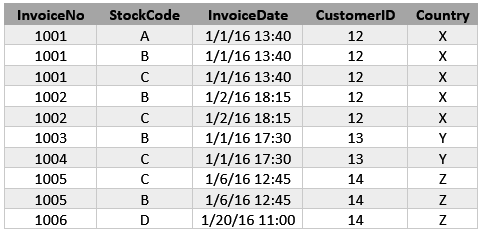

You can either crosstab it based on each Invoice ID like this one:

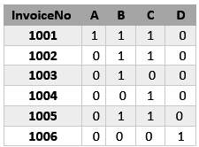

```r
#Reshape the dataset
library(reshape2)
mlt1 = melt(dt1,id.vars =  names(dt1)[c(1,3:5)])
dt2 <- dcast(mlt1, CustomerID  ~ value, value.var = c("CustomerID"),fun.aggregate =length)
#Remove first variable containing the CustomerID
dt3 <- dt2[, -1]
```

Then we have to reduce the dimensionality because we have 260 variables. For this purpose, we can use Principal component Analysis (PCA) but if you are using another dataset, make sure that a number of columns (variables) are less than a number of rows (records) otherwise you cannot apply PCA. Moreover, it is a better approach to standardize the dataset before applying PCA. This dataset is highly biased like many other datasets so, many values in “dt3” are zero. You can use normalization or standardization or like us, you can just use binary indicators for each variable (which are products here) in which zero means “not bought” and 1 means “at least bought once”. Then we transformed all the variables to numeric and used PCA to reduce the dimensions to 6.

```r
#Transform dataset
for (i in 1:ncol(dt3)){
  dt3[,i] <- ifelse(dt3[,i]==0,0,1)
}
#Apply PCA
for (i in 1:ncol(dt3)){
  dt3[, i] <- as.numeric(dt3[, i])
}
pcaout <- prcomp(dt3)
pcdt <- pcaout$x[,1:6]
```

Next, we used K-means clustering and Davies-Bouldin index to cluster and find the best number of clusters. The less the Davies-Bouldin index is the better the clusters are. You have to install `clusterCrit` before running this function. This function has four arguments. First is dataset you want to cluster, second is the minimum value of K and the third one is the maximum number of K and finally “rnd” which indicates the random seed for clustering. The output of this function would be Davies-Bouldin index. If your dataset is huge and wants to see the progress of clustering, you might use `print(paste0("K is equal to= ",j))` which is set to comment here.

```r
#Clustering Function
kmcl <- function(data, kmin, kmax, rnd = 1357){
  library(clusterCrit)
  DB <- c()
  for (i in 1:ncol(data))
  {
    data[, i] <- as.numeric(data[, i])
  }
  for (j in kmin:kmax)
  {
    set.seed(rnd)
    km <- kmeans(data, centers = j)
    data1 <- as.matrix(data)
    # Computing the Davies-Bouldin
    DB[j] <- intCriteria(data1, km$cluster, crit = c("Davies_Bouldin"))
    #print(paste0("K is equal to= ",j))
  }
  return(DB)
}
```

In order to better show the Davies-Bouldin values along with a different number of clusters, we created the following function for plotting the output of clustering function.

```r
#Davies-Bouldin Plot
dbplot <- function(obj, tit1 = "Null"){
  plot(2:15, unlist(obj), type = "o", col = "black", ylim = c(0, 3),
       lwd = 2, ylab = "DB Vlaue", xlab = "Number of Clusters", cex.lab = 1.5,
       cex.axis = 0.75)
  grid(nx = 25, ny = 25, col = "lightgray", lty = "dotted", lwd = par("lwd"),
       equilogs = TRUE)
  axis(side = 1, at = seq(2, 15, by = 1), cex.axis = 0.75)
  box(col = "black", lwd = 2)
  title(tit1)
}
```